# Partie géosom de la procédure OSM

Chargement du package

```python
from geosom_pck.process import *
from geosom_pck.evaluation import *
from geosom_pck.viz import *
```

```python
np.set_printoptions(suppress=True, precision=4, linewidth=1000)
```

```python
bd_osm_data = Data("bd_osm.tsv")

bd_sbd_data = Data("bd_sbd.tsv")
```

Compte du nombre de bâtiments dans chaque DS

```python
print("OSM: " + str(len(np.array(list(bd_osm_data.values())))))
print("SBD: " + str(len(np.array(list(bd_sbd_data.values())))))
```

```
OSM: 6447
SBD: 6151
```

Sélection du nombre de neurones en X et Y, $\simeq$ un neurone par bâtiment et des proportions correspondantes à celles de la bbox sur Lausanne

```python
(93*70) % (len(np.array(list(bd_osm_data.values()))))
```

```
63
```

```python
bd_osm_cod = georandinit((93, 70), bd_osm_data)
bd_sbd_cod = georandinit((93, 70), bd_sbd_data)
```

```python
bd_osm_data.maxval
```

```
array([540993.5, 155812. ,      1. ,      1. ,      1. ,      1. ,      1. ,      1. ,      1. ,      1. ,      1. ,      1. ,      1. ,      1. ,      1. ,      1. ,      1. ,      1. ,      1. ,      1. ,      1. ,      1. ,      1. ,      1. ,      1. ,      1. ,      1. ,      1. ,      1. ,    …
```

```python
bd_osm_cod
```

[output not shown]

### Geosom - OSM

```python
vgeosom(cod = bd_osm_cod, data = bd_osm_data, k = 2)
```

```python
qerror(cod=bd_osm_cod, data=bd_osm_data)
```

```
[830.3218311285435, 0.027849153939877316]
```

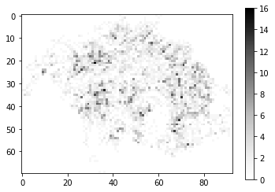

```python
a = hitmap(bd_osm_cod, bd_osm_data, geo=True)
```

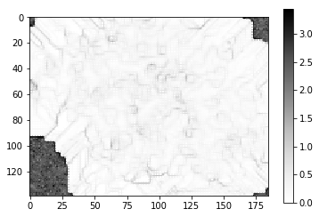

```
array([[[2.7273],
        [2.7967],
        [2.4398],
        ...,
        [2.5562],
        [2.4645],
        [2.4769]],

       [[2.8165],
        [2.5246],
        [2.4335],
        ...,
        [2.7212],
        [2.4866],
        [2.5826]],

       [[2.5019],
        [2.2375],
        [2.3753],
        ...,
        [2.5521],
        [2.6995],
        [2.4476]],

       ...,

       [[2.4511],
        [2.0876],
        [2.498 ],
        ...,
        [1.8537],
        [2.3559],
        [2.4935]],

       [[2.241 ],
        [2.556 ],
        [2.5021],
        ...,
        [2.7711],
        [2.8703],
        [2.3385]],

       [[2.347 ],
        [2.1462],
        [2.3418],
        ...,
        [2.7489],
        [2.6633],
        [2.6785]]])
```

```python
correctUmat(bd_osm_cod)
```

```python
n = 15
test = np.reshape(np.zeros((2*n)-2), (n-1, 2))
for i in range(1, n):
    t = kmns_on_cod(cod = bd_osm_cod, k_nbrs=i)
    test[i-1] = [i, t.inertia_]
```

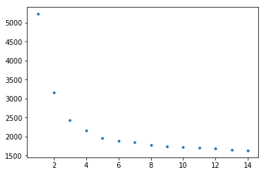

```python
plt.plot(test[:,0], test[:,1], '.')
```

```python
osm_kms_07 = kmns_on_cod(cod=bd_osm_cod, k_nbrs=7)
osm_kms_12 = kmns_on_cod(cod=bd_osm_cod, k_nbrs=12)
```

```
array([[2, 2, 2, ..., 2, 2, 2],
       [2, 2, 2, ..., 2, 2, 2],
       [5, 1, 4, ..., 2, 2, 2],
       ...,
       [2, 2, 2, ..., 1, 4, 2],
       [2, 2, 2, ..., 1, 1, 2],
       [2, 2, 2, ..., 2, 2, 2]])
```

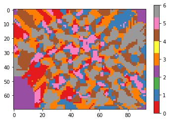

```python
kms_rslt(osm_kms_07, bd_osm_cod)
```

```
array([[ 8, 10, 11, ...,  1,  8, 11],
       [10, 10,  1, ...,  1, 11,  1],
       [ 4,  3,  2, ..., 10, 10,  8],
       ...,
       [10,  8, 10, ...,  3,  2,  8],
       [11, 11,  1, ...,  3,  3, 10],
       [11,  1,  8, ...,  8, 11,  8]])
```

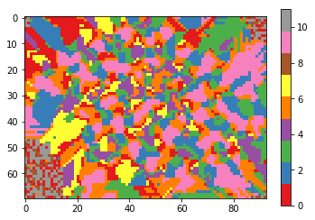

```python
kms_rslt(osm_kms_12, bd_osm_cod)
```

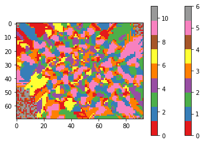

```python
osm_rslt_07 = attribution_array(bd_osm_data, bd_osm_cod, kms_rslt(osm_kms_07, bd_osm_cod), geo = True)
osm_rslt_12 = attribution_array(bd_osm_data, bd_osm_cod, kms_rslt(osm_kms_12, bd_osm_cod), geo = True)
```

```python
export_cat_csv(osm_rslt_07, "rslt_osm_07_geo.csv")
export_cat_csv(osm_rslt_12, "rslt_osm_12_geo.csv")
```

### GeoSOM - SBD

```python
datetime.datetime.now()
```

```
datetime.datetime(2019, 5, 27, 17, 48, 10, 686756)
```

```python
vgeosom(cod = bd_sbd_cod, data = bd_sbd_data, k = 2)
```

```python
datetime.datetime.now()
```

```
datetime.datetime(2019, 5, 27, 19, 18, 32, 281170)
```

```python
qerror(cod=bd_sbd_cod, data=bd_sbd_data)
```

```
[852.0844571066082, 0.02505735050251054]
```

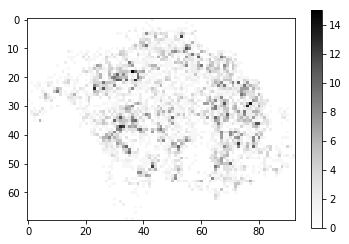

```python
a = hitmap(bd_sbd_cod, bd_sbd_data, geo=True)
```

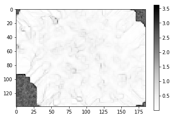

```
array([[[2.5011],
        [2.3632],
        [2.447 ],
        ...,
        [2.3738],
        [2.0733],
        [2.4004]],

       [[2.492 ],
        [2.5897],
        [2.18  ],
        ...,
        [2.3495],
        [2.6258],
        [2.4002]],

       [[2.4253],
        [2.7171],
        [2.5358],
        ...,
        [2.4198],
        [2.5429],
        [2.4562]],

       ...,

       [[2.4616],
        [2.3519],
        [2.5156],
        ...,
        [2.5402],
        [2.4499],
        [2.6869]],

       [[2.3965],
        [2.4306],
        [2.9331],
        ...,
        [2.2266],
        [2.4819],
        [2.186 ]],

       [[2.344 ],
        [2.0447],
        [2.4126],
        ...,
        [2.2427],
        [2.0968],
        [2.2426]]])
```

```python
correctUmat(bd_sbd_cod)
```

```python
n = 15
test = np.reshape(np.zeros((2*n)-2), (n-1, 2))
for i in range(1, n):
    t = kmns_on_cod(cod = bd_sbd_cod, k_nbrs=i)
    test[i-1] = [i, t.inertia_]
```

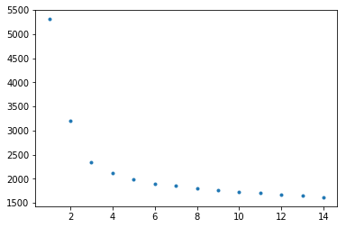

```python
plt.plot(test[:,0], test[:,1], '.')
```

```python
sbd_kms_07 = kmns_on_cod(cod=bd_sbd_cod, k_nbrs=7)
sbd_kms_12 = kmns_on_cod(cod=bd_sbd_cod, k_nbrs=12)
```

```
array([[1, 4, 4, ..., 1, 4, 1],
       [1, 4, 4, ..., 4, 1, 4],
       [1, 1, 0, ..., 1, 4, 4],
       ...,
       [4, 4, 4, ..., 5, 5, 1],
       [1, 4, 1, ..., 4, 4, 1],
       [1, 1, 1, ..., 4, 1, 4]])
```

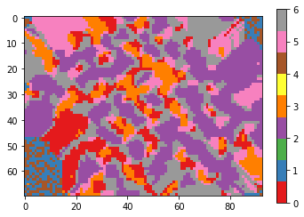

```python
kms_rslt(sbd_kms_07, bd_sbd_cod)
```

```
array([[3, 5, 3, ..., 5, 5, 4],
       [3, 8, 3, ..., 4, 3, 3],
       [3, 3, 2, ..., 8, 5, 5],
       ...,
       [3, 8, 4, ..., 7, 7, 4],
       [3, 5, 5, ..., 5, 5, 4],
       [3, 3, 4, ..., 3, 4, 4]])
```

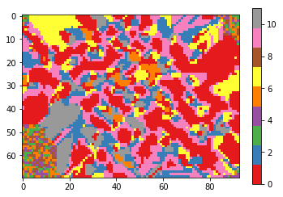

```python
kms_rslt(sbd_kms_12, bd_sbd_cod)
```

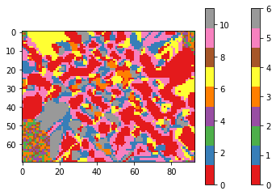

```python
sbd_rslt_07 = attribution_array(bd_sbd_data, bd_sbd_cod, kms_rslt(sbd_kms_07, bd_sbd_cod), geo = True)
sbd_rslt_12 = attribution_array(bd_sbd_data, bd_sbd_cod, kms_rslt(sbd_kms_12, bd_sbd_cod), geo = True)
```

```python
export_cat_csv(sbd_rslt_07, "rslt_sbd_07_geo.csv")
export_cat_csv(sbd_rslt_12, "rslt_sbd_12_geo.csv")
```

```python
datetime.datetime.now()
```

## Essais avec les éléments triés

```python
bd_osmt_data = Data("bd_osm_tri.tsv")
```

```python
print("OSM: " + str(len(np.array(list(bd_osmt_data.values())))))
```

```
OSM: 6420
```

```python
(92*70) % (len(np.array(list(bd_osmt_data.values()))))
```

```
20
```

```python
bd_osmt_cod = georandinit((92, 70), bd_osmt_data)
```

```python
vgeosom(cod = bd_osmt_cod, data = bd_osmt_data, k = 2)
```

```python
qerror(cod=bd_osmt_cod, data=bd_osmt_data)
```

```
[842.652570573217, 0.00536281567072412]
```

```python
import datetime
datetime.datetime.now()
```

```
datetime.datetime(2019, 6, 6, 13, 12, 12, 984899)
```

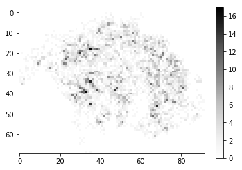

```python
a = hitmap(bd_osmt_cod, bd_osmt_data, geo=True)
```

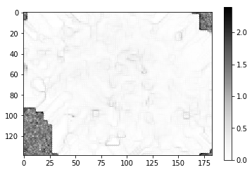

```python
cu = correctUmat(bd_osmt_cod)
```

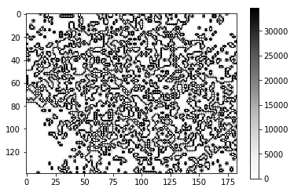

```python
cu2 = correctUmat(cod = modify_cod_without_hit(bd_osmt_cod, bd_osmt_data))
```

```python
bd_osmt_cod_mod = modify_cod_without_hit(bd_osmt_cod, bd_osmt_data)
```

```python
n = 15
test = np.reshape(np.zeros((2*n)-2), (n-1, 2))
for i in range(1, n):
    t = kmns_on_cod(cod = bd_osmt_cod_mod, k_nbrs=i)
    test[i-1] = [i, t.inertia_]
```

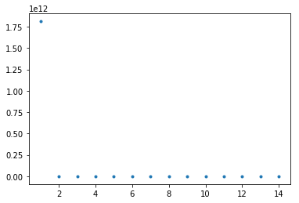

```python
plt.plot(test[:,0], test[:,1], '.')
```

```python
osmt_kms_07 = kmns_on_cod(cod=bd_osmt_cod_mod, k_nbrs=7)
osmt_kms_12 = kmns_on_cod(cod=bd_osmt_cod_mod, k_nbrs=12)
```

```
array([[0, 0, 0, ..., 0, 0, 0],
       [0, 0, 0, ..., 0, 0, 0],
       [0, 0, 0, ..., 0, 0, 0],
       ...,
       [0, 0, 0, ..., 3, 4, 0],
       [0, 0, 0, ..., 0, 0, 0],
       [0, 0, 0, ..., 0, 0, 0]])
```

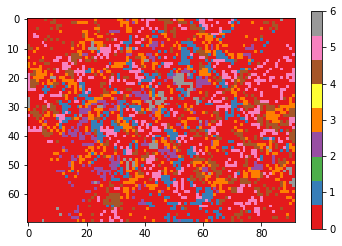

```python
kms_rslt(osmt_kms_07, bd_osmt_cod_mod)
```

```
array([[0, 0, 0, ..., 0, 0, 0],
       [0, 0, 0, ..., 0, 0, 0],
       [0, 0, 0, ..., 0, 0, 0],
       ...,
       [0, 0, 0, ..., 8, 8, 0],
       [0, 0, 0, ..., 0, 0, 0],
       [0, 0, 0, ..., 0, 0, 0]])
```

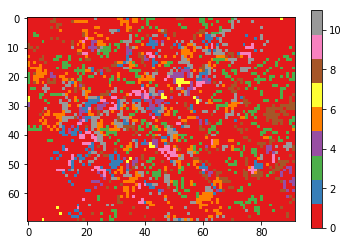

```python
kms_rslt(osmt_kms_12, bd_osmt_cod_mod)
```

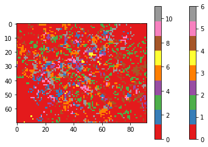

```python
osmt_rslt_07 = attribution_array(bd_osmt_data, bd_osmt_cod_mod, kms_rslt(osmt_kms_07, bd_osmt_cod_mod), geo = True)
osmt_rslt_12 = attribution_array(bd_osmt_data, bd_osmt_cod_mod, kms_rslt(osmt_kms_12, bd_osmt_cod_mod), geo = True)
```

```python
export_cat_csv(osmt_rslt_07, "rslt_osmt_07_geo_mod.csv")
export_cat_csv(osmt_rslt_12, "rslt_osmt_12_geo_mod.csv")
```

# Partie GeoSOM de la procédure OSM

## Essais avec différents seuils de tolérance *k*

Dans cette partie, plusieurs seuils *k* sont testés afin de voir s'ils améliorent ou non la classification en élargissant le champ de recherche des neurones voisins.

Les tests sont effectués avec les seuils suivants :

- 1
- 2
- 3
- 4

Le GeoSOM est appliqué 2x fois, la première avec les paramètres suivants:

- Itérations: 1000
- $\alpha$: 0.05
- Rayon: 10

Le cod résultant est corrigé pour éliminer les neurones ne comprenant pas d'entité

Un K-Means est alors appliqué sur les cods résultants afin d'obtenir des classes (une des classes sera attribuée aux éléments sans entité (*no hit*).

Il faudra encore définir le nombre de classes du K-Means en observant les différents résultats.

#### Préparation des éléments généraux

```python
from geosom_pck.process import *
from geosom_pck.evaluation import *
from geosom_pck.viz import *
import datetime
```

```python
np.set_printoptions(suppress=True, precision=4, linewidth=1000)
```

```python
bd_osmt_data = Data("bd_osm_tri.tsv")
```

```python
print("OSM: " + str(len(np.array(list(bd_osmt_data.values())))))
```

```
OSM: 6420
```

```python
(92*70) % (len(np.array(list(bd_osmt_data.values()))))
```

```
20
```

### Seuil à *k* = 1 (voisins directs)

#### Analyse

```python
bd_osmt_cod = georandinit((92, 70), bd_osmt_data)
```

```python
datetime.datetime.now()
```

```
datetime.datetime(2019, 6, 11, 11, 17, 48, 783900)
```

```python
vgeosom(cod = bd_osmt_cod, data = bd_osmt_data, rlen = 1000, alpha = 0.05, radius= 10, k = 1)
```

```python
datetime.datetime.now()
```

```
datetime.datetime(2019, 6, 11, 12, 39, 45, 317683)
```

```python
qerror(cod=bd_osmt_cod, data=bd_osmt_data)
```

```
[842.652570573217, 0.009609269159478923]
```

```python
datetime.datetime.now()
```

```
datetime.datetime(2019, 6, 11, 12, 44, 12, 362593)
```

```python
vgeosom(cod = bd_osmt_cod, data = bd_osmt_data, rlen = 1000, alpha = 0.05, radius = 4, k = 1)
```

```python
datetime.datetime.now()
```

```
datetime.datetime(2019, 6, 11, 14, 18, 57, 574716)
```

```python
qerror(cod=bd_osmt_cod, data=bd_osmt_data)
```

```
[842.652570573217, 0.0064190385397147765]
```

#### Visualisation rslt

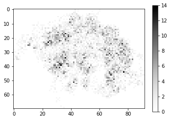

```python
hmap_k1 = hitmap(bd_osmt_cod, bd_osmt_data, geo=True, r = 1)
```

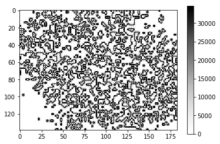

```python
umat_k1 = correctUmat(cod = modify_cod_without_hit(bd_osmt_cod, bd_osmt_data))
```

```python
bd_osmt_cod_k1_mod = modify_cod_without_hit(bd_osmt_cod, bd_osmt_data)
```

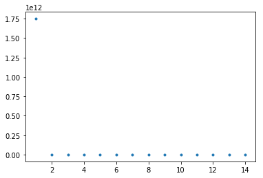

```python
n = 15
test = np.reshape(np.zeros((2*n)-2), (n-1, 2))
for i in range(1, n):
    t = kmns_on_cod(cod = bd_osmt_cod_k1_mod, k_nbrs=i)
    test[i-1] = [i, t.inertia_]

plt.plot(test[:,0], test[:,1], '.')
```

#### K-Means

```python
osmt_k1_kms_08 = kmns_on_cod(cod=bd_osmt_cod_k1_mod, k_nbrs=8)
osmt_k1_kms_12 = kmns_on_cod(cod=bd_osmt_cod_k1_mod, k_nbrs=12)
```

```
array([[0, 0, 0, ..., 0, 0, 0],
       [0, 0, 0, ..., 0, 0, 0],
       [0, 0, 0, ..., 0, 0, 0],
       ...,
       [0, 0, 0, ..., 0, 0, 0],
       [0, 0, 0, ..., 0, 0, 0],
       [0, 0, 0, ..., 0, 0, 0]])
```

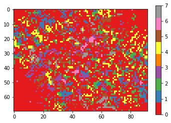

```python
kms_rslt(osmt_k1_kms_08, bd_osmt_cod_k1_mod)
```

```
array([[0, 0, 0, ..., 0, 0, 0],
       [0, 0, 0, ..., 0, 0, 0],
       [0, 0, 0, ..., 0, 0, 0],
       ...,
       [0, 0, 0, ..., 0, 0, 0],
       [0, 0, 0, ..., 0, 0, 0],
       [0, 0, 0, ..., 0, 0, 0]])
```

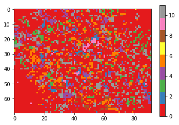

```python
kms_rslt(osmt_k1_kms_12, bd_osmt_cod_k1_mod)
```

#### Exportation

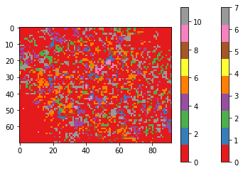

```python
osmt_k1_rslt_08 = attribution_array(bd_osmt_data, bd_osmt_cod_k1_mod, kms_rslt(osmt_k1_kms_08, bd_osmt_cod_k1_mod), geo = True, k=1)
osmt_k1_rslt_12 = attribution_array(bd_osmt_data, bd_osmt_cod_k1_mod, kms_rslt(osmt_k1_kms_12, bd_osmt_cod_k1_mod), geo = True, k=1)
```

```python
export_cat_csv(osmt_k1_rslt_08, "rslt_osmt_08_geo_mod_k1.csv")
export_cat_csv(osmt_k1_rslt_12, "rslt_osmt_12_geo_mod_k1.csv")
```

### Seuil à k = 2

```python
bd_osmt_cod_k2 = georandinit((92, 70), bd_osmt_data)
```

```python
datetime.datetime.now()
```

```
datetime.datetime(2019, 6, 11, 15, 45, 28, 219917)
```

```python
vgeosom(cod = bd_osmt_cod_k2, data = bd_osmt_data, rlen = 1000, alpha = 0.05, radius= 10, k = 2)
```

```python
qerror(cod=bd_osmt_cod_k2, data=bd_osmt_data)
```

```
[842.652570573217, 0.007759072756285605]
```

```python
datetime.datetime.now()
```

```
datetime.datetime(2019, 6, 11, 17, 9, 15, 162030)
```

```python
datetime.datetime.now()
```

```
datetime.datetime(2019, 6, 11, 17, 32, 54, 502585)
```

```python
vgeosom(cod = bd_osmt_cod_k2, data = bd_osmt_data, rlen = 1000, alpha = 0.05, radius = 4, k = 2)
```

```python
datetime.datetime.now()
```

```
datetime.datetime(2019, 6, 11, 18, 50, 19, 34554)
```

```python
qerror(cod=bd_osmt_cod_k2, data=bd_osmt_data)
```

```
[842.652570573217, 0.0053643060361098565]
```

#### Visualisation

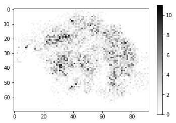

```python
hmap_k2 = hitmap(bd_osmt_cod_k2, bd_osmt_data, geo=True, r = 2)
```

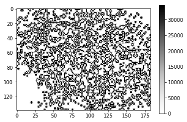

```python
umat_k2 = correctUmat(cod = modify_cod_without_hit(bd_osmt_cod_k2, bd_osmt_data))
```

```python
bd_osmt_cod_k2_mod = modify_cod_without_hit(bd_osmt_cod_k2, bd_osmt_data)
```

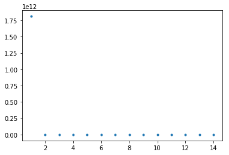

```python
n = 15
test = np.reshape(np.zeros((2*n)-2), (n-1, 2))
for i in range(1, n):
    t = kmns_on_cod(cod = bd_osmt_cod_k2_mod, k_nbrs=i)
    test[i-1] = [i, t.inertia_]

plt.plot(test[:,0], test[:,1], '.')
```

#### K-Means

```python
osmt_k2_kms_08 = kmns_on_cod(cod=bd_osmt_cod_k2_mod, k_nbrs=8)
osmt_k2_kms_12 = kmns_on_cod(cod=bd_osmt_cod_k2_mod, k_nbrs=12)
```

```
array([[1, 1, 1, ..., 1, 1, 1],
       [1, 1, 1, ..., 1, 1, 1],
       [1, 1, 1, ..., 1, 1, 1],
       ...,
       [1, 1, 1, ..., 1, 1, 1],
       [1, 1, 1, ..., 1, 1, 1],
       [1, 1, 1, ..., 1, 1, 1]])
```

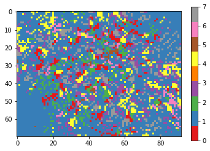

```python
kms_rslt(osmt_k2_kms_08, bd_osmt_cod_k2_mod)
```

```
array([[0, 0, 0, ..., 0, 0, 0],
       [0, 0, 0, ..., 0, 0, 0],
       [0, 0, 0, ..., 0, 0, 0],
       ...,
       [0, 0, 0, ..., 0, 0, 0],
       [0, 0, 0, ..., 0, 0, 0],
       [0, 0, 0, ..., 0, 0, 0]])
```

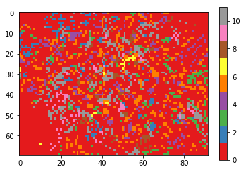

```python
kms_rslt(osmt_k2_kms_12, bd_osmt_cod_k2_mod)
```

#### Exportation

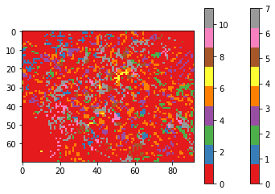

```python
osmt_k2_rslt_08 = attribution_array(bd_osmt_data, bd_osmt_cod_k2_mod, kms_rslt(osmt_k2_kms_08, bd_osmt_cod_k2_mod), geo = True, k=2)
osmt_k2_rslt_12 = attribution_array(bd_osmt_data, bd_osmt_cod_k2_mod, kms_rslt(osmt_k2_kms_12, bd_osmt_cod_k2_mod), geo = True, k=2)
```

```python
export_cat_csv(osmt_k2_rslt_08, "rslt_osmt_08_geo_mod_k2.csv")
export_cat_csv(osmt_k2_rslt_12, "rslt_osmt_12_geo_mod_k2.csv")
```

### Seuil à k = 3

```python
bd_osmt_cod_k3 = georandinit((92, 70), bd_osmt_data)
```

```python
datetime.datetime.now()
```

```
datetime.datetime(2019, 6, 18, 12, 21, 42, 238850)
```

```python
vgeosom(cod = bd_osmt_cod_k3, data = bd_osmt_data, rlen = 1000, alpha = 0.05, radius= 10, k = 3)
```

```python
qerror(cod=bd_osmt_cod_k3, data=bd_osmt_data)
```

```
[842.652570573217, 0.007103820618781544]
```

```python
datetime.datetime.now()
```

```
datetime.datetime(2019, 6, 18, 13, 45, 46, 431535)
```

```python
datetime.datetime.now()
```

[output not shown]

```python
vgeosom(cod = bd_osmt_cod_k3, data = bd_osmt_data, rlen = 1000, alpha = 0.05, radius = 4, k = 3)
```

```python
datetime.datetime.now()
```

[output not shown]

```python
qerror(cod=bd_osmt_cod_k3, data=bd_osmt_data)
```

[output not shown]

#### Visualisation

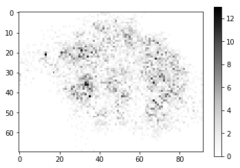

```python
hmap_k3 = hitmap(bd_osmt_cod_k3, bd_osmt_data, geo=True, r = 3)
```

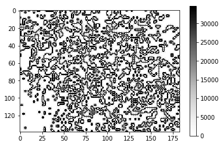

```python
umat_k3 = correctUmat(cod = modify_cod_without_hit(bd_osmt_cod_k3, bd_osmt_data))
```

```python
bd_osmt_cod_k3_mod = modify_cod_without_hit(bd_osmt_cod_k3, bd_osmt_data)
```

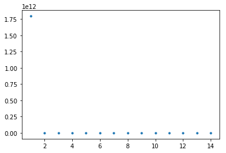

```python
n = 15
test = np.reshape(np.zeros((2*n)-2), (n-1, 2))
for i in range(1, n):
    t = kmns_on_cod(cod = bd_osmt_cod_k3_mod, k_nbrs=i)
    test[i-1] = [i, t.inertia_]

plt.plot(test[:,0], test[:,1], '.')
```

#### K-Means

```python
osmt_k3_kms_08 = kmns_on_cod(cod=bd_osmt_cod_k3_mod, k_nbrs=8)
osmt_k3_kms_12 = kmns_on_cod(cod=bd_osmt_cod_k3_mod, k_nbrs=12)
```

```
array([[0, 0, 0, ..., 0, 0, 0],
       [3, 0, 0, ..., 0, 0, 0],
       [0, 0, 0, ..., 0, 0, 0],
       ...,
       [0, 0, 0, ..., 0, 0, 0],
       [0, 0, 0, ..., 0, 0, 0],
       [0, 0, 0, ..., 0, 0, 0]])
```

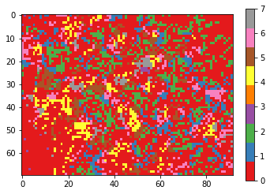

```python
kms_rslt(osmt_k3_kms_08, bd_osmt_cod_k3_mod)
```

```
array([[0, 0, 0, ..., 0, 0, 0],
       [5, 0, 0, ..., 0, 0, 0],
       [0, 0, 0, ..., 0, 0, 0],
       ...,
       [0, 0, 0, ..., 0, 0, 0],
       [0, 0, 0, ..., 0, 0, 0],
       [0, 0, 0, ..., 0, 0, 0]])
```

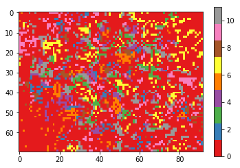

```python
kms_rslt(osmt_k3_kms_12, bd_osmt_cod_k3_mod)
```

#### Exportation

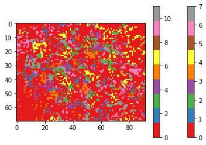

```python
osmt_k3_rslt_08 = attribution_array(bd_osmt_data, bd_osmt_cod_k3_mod, kms_rslt(osmt_k3_kms_08, bd_osmt_cod_k3_mod), geo = True, k=3)
osmt_k3_rslt_12 = attribution_array(bd_osmt_data, bd_osmt_cod_k3_mod, kms_rslt(osmt_k3_kms_12, bd_osmt_cod_k3_mod), geo = True, k=3)
```

```python
export_cat_csv(osmt_k3_rslt_08, "rslt_osmt_08_geo_mod_k3.csv")
export_cat_csv(osmt_k3_rslt_12, "rslt_osmt_12_geo_mod_k3.csv")
```

#### Test d'export du cod

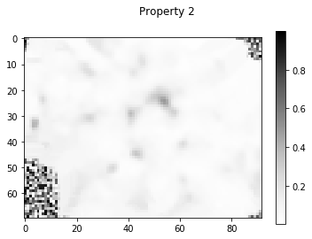

```python
plot_property(bd_osmt_cod_k3, col_number=2, geo = True)
```

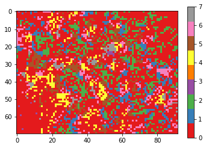

```python
cod_to_export = modify_cod_with_kmrslt(bd_osmt_cod_k3_mod, kms_rslt(osmt_k3_kms_08, bd_osmt_cod_k3_mod))
```

```python
export_cod_to_csv(cod_to_export, "cod_kmeans.csv")
```

```python
bd_osmt_data.minval
```

```
array([534745.2, 150723.9,      0. ,      0. ,      0. ,      0. ,      0. ,      0. ,      0. ,      0. ,      0. ,      0. ,      0. ,      0. ])
```

```python
osmt_k3_kms_08.cluster_centers_
```

```
array([[-9999.    , -9999.    , -9999.    , -9999.    , -9999.    , -9999.    , -9999.    , -9999.    , -9999.    , -9999.    , -9999.    , -9999.    ],
       [    0.0445,     0.0102,     0.1041,     0.0945,     0.0764,     0.4617,     0.4305,     0.0468,     0.0091,     0.9441,     0.02  ,     0.0143],
       [    0.0381,     0.0093,     0.1053,     0.076 ,     0.1056,     0.615 ,     0.6258,     0.019 ,     0.0079,     0.9696,     0.0166,     0.0079],
       [    0.5035,     0.3121,     0.3127,     0.2718,     0.2911,     0.2655,     0.2954,     0.1504,     0.3086,     0.3914,     0.4572,     0.4435],
       [    0.1021,     0.0302,     0.1595,     0.2201,     0.2052,     0.2242,     0.1878,     0.1437,     0.0302,     0.9244,     0.0399,     0.0488],
       [    0.0721,     0.0235,     0.168 ,     0.1614,     0.2341,     0.428 ,     0.3914,     0.0525,     0.0207,     0.9634,     0.0208,     0.0244],
       [    0.0771,     0.0209,     0.1297,     0.1259,     0.1162,     0.3456,     0.303 ,     0.0532,     0.0216,     0.8574,     0.0575,     0.0365],
       [    0.2203,     0.0849,     0.2159,     0.2401,     0.2325,     0.239 ,     0.1952,     0.077 ,     0.0987,     0.6481,     0.1739,     0.1369]])
```

```python
osmt_k3_kms_08.inertia_
```

```
62.36870565217576
```

### Seuil à k = 4

```python
bd_osmt_cod_k4 = georandinit((92, 70), bd_osmt_data)
```

```python
datetime.datetime.now()
```

```
datetime.datetime(2019, 6, 12, 7, 32, 37, 349208)
```

```python
vgeosom(cod = bd_osmt_cod_k4, data = bd_osmt_data, rlen = 1000, alpha = 0.05, radius= 10, k = 4)
```

```python
qerror(cod=bd_osmt_cod_k4, data=bd_osmt_data)
```

```
[842.652570573217, 0.006558916190684066]
```

```python
datetime.datetime.now()
```

```
datetime.datetime(2019, 6, 12, 8, 53, 37, 967296)
```

```python
datetime.datetime.now()
```

```
datetime.datetime(2019, 6, 12, 8, 53, 55, 417312)
```

```python
vgeosom(cod = bd_osmt_cod_k4, data = bd_osmt_data, rlen = 1000, alpha = 0.05, radius = 4, k = 4)
```

```python
datetime.datetime.now()
```

```
datetime.datetime(2019, 6, 12, 10, 16, 16, 460550)
```

```python
qerror(cod=bd_osmt_cod_k4, data=bd_osmt_data)
```

```
[842.652570573217, 0.004524957619700368]
```

#### Visualisation

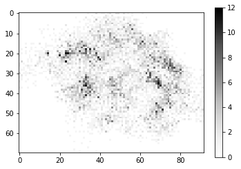

```python
hmap_k4 = hitmap(bd_osmt_cod_k4, bd_osmt_data, geo=True, r = 4)
```

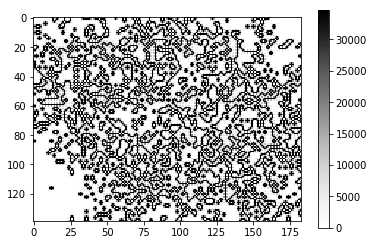

```python
umat_k4 = correctUmat(cod = modify_cod_without_hit(bd_osmt_cod_k4, bd_osmt_data))
```

```python
bd_osmt_cod_k4_mod = modify_cod_without_hit(bd_osmt_cod_k4, bd_osmt_data)
```

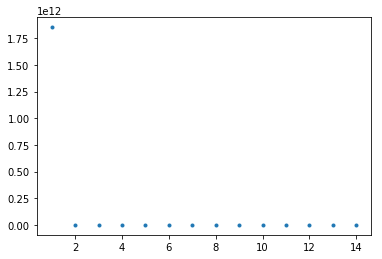

```python
n = 15
test = np.reshape(np.zeros((2*n)-2), (n-1, 2))
for i in range(1, n):
    t = kmns_on_cod(cod = bd_osmt_cod_k4_mod, k_nbrs=i)
    test[i-1] = [i, t.inertia_]

plt.plot(test[:,0], test[:,1], '.')
```

#### K-Means

```python
osmt_k4_kms_08 = kmns_on_cod(cod=bd_osmt_cod_k4_mod, k_nbrs=8)
osmt_k4_kms_12 = kmns_on_cod(cod=bd_osmt_cod_k4_mod, k_nbrs=12)
```

```
array([[0, 0, 0, ..., 0, 0, 0],
       [0, 0, 0, ..., 0, 0, 0],
       [0, 0, 0, ..., 0, 0, 0],
       ...,
       [0, 0, 0, ..., 0, 0, 0],
       [0, 0, 0, ..., 0, 0, 0],
       [0, 0, 0, ..., 5, 0, 0]])
```

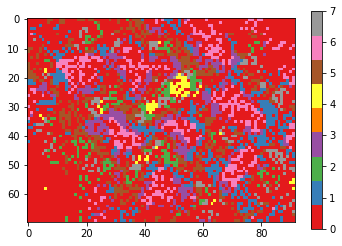

```python
kms_rslt(osmt_k4_kms_08, bd_osmt_cod_k4_mod)
```

```
array([[0, 0, 0, ..., 0, 0, 0],
       [0, 0, 0, ..., 0, 0, 0],
       [0, 0, 0, ..., 0, 0, 0],
       ...,
       [0, 0, 0, ..., 0, 0, 0],
       [0, 0, 0, ..., 0, 0, 0],
       [0, 0, 0, ..., 6, 0, 0]])
```

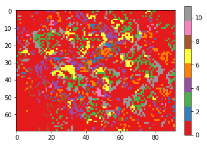

```python
kms_rslt(osmt_k4_kms_12, bd_osmt_cod_k4_mod)
```

#### Exportation

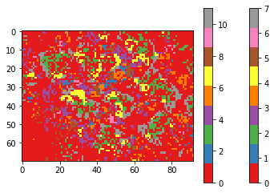

```python
osmt_k4_rslt_08 = attribution_array(bd_osmt_data, bd_osmt_cod_k4_mod, kms_rslt(osmt_k4_kms_08, bd_osmt_cod_k4_mod), geo = True, k=4)
osmt_k4_rslt_12 = attribution_array(bd_osmt_data, bd_osmt_cod_k4_mod, kms_rslt(osmt_k4_kms_12, bd_osmt_cod_k4_mod), geo = True, k=4)
```

```python
export_cat_csv(osmt_k4_rslt_08, "rslt_osmt_08_geo_mod_k4.csv")
export_cat_csv(osmt_k4_rslt_12, "rslt_osmt_12_geo_mod_k4.csv")
```